# Dropout Pattern

Julian Frattini

2026-03-17

This notebook investigates the dropout pattern in the 2024 run of NaPiRE.

## Data Loading

First, we determine the variables of interest. These are all the quantitative columns from closed-ended questions.

```r
vars.meta <- c("v_3", "v_23", "Country", "ISO", "v_1", "v_457", "v_16", "v_357", "v_377", "v_17")
vars.communication <- c("v_25", "v_359", "v_452", "v_380", "v_368")
vars.elicitation <- c("v_28", "v_29", "v_572", "v_34", "v_36", "v_37", "v_38", "v_39", "v_40", "v_41", "v_42", "v_43",
         "v_44", "v_47", "v_667", "v_668", "v_669", "v_461", "v_454", "v_45")
vars.assumption <- c("v_455")
vars.benefit <- c("v_482", "v_484", "v_487")
vars.documentation <- c("v_76", "v_73", "v_79", "v_68", "v_70", "v_71", "v_74", "v_78", "v_77", "v_75", "v_69", "v_72",
         "v_466", "v_557", "v_576", "v_80",
         "v_87", "v_92", "v_88", "v_91", "v_83", "v_93", "v_89", "v_90", "v_84", "v_86", "v_82", "v_85",
         "v_463", "v_558", "v_575", "v_95",
         "v_577",
         "v_670", "v_671", "v_672", "v_673", "v_674", "v_675", "v_676", "v_677")
vars.nfrs <- c("v_97", "v_98", "v_99", "v_100", "v_101", "v_102", "v_303", "v_103", "v_422", "v_104")
vars.reasons <- c("v_559", "v_560", "v_561", "v_562", "v_563", "v_564", "v_565", "v_566", "v_567", "v_568", "v_569")
vars.validation <- c("v_158", "v_159", "v_160", "v_161", "v_162", "v_573", "v_574", "v_163")
vars.problems <- c("v_385", "v_386", "v_418", "v_409", "v_410", "v_388", "v_389", "v_392", "v_393", "v_394",
         "v_395", "v_396", "v_397", "v_399", "v_401", "v_402", "v_403", "v_404", "v_411", "v_405",
         "v_408", "v_407", "v_406", "v_387", "v_417", "v_459", "v_571")
vars.top <- c("v_661", "v_662", "v_663", "v_664", "v_665")

vars <- c(vars.meta, vars.communication, vars.elicitation, vars.assumption, vars.benefit,
          vars.documentation, vars.nfrs, vars.reasons, vars.validation, vars.problems,
          vars.top)

var_groups <- list(
  "Demographics" = vars.meta,
  "Communication" = vars.communication,
  "Requirements Elicitation" = vars.elicitation,
  "Assumptions" = vars.assumption,
  "Unknown Benefit" = vars.benefit,
  "Documentation" = vars.documentation,
  "Non-functional Requirements"  = vars.nfrs,
  "Analysis" = vars.reasons,
  "Validation" = vars.validation
)
```

Then, we load the data and retain only the relevant variables.

```r
d <- load_data_2024(data_path = "../../data", file = "data_preprocessed.csv") %>%
  select(all_of(vars))

n <- nrow(d)
```

## Data Visualization

Finally, we can visualize the number of available and missing data points per column, grouped by survey section.

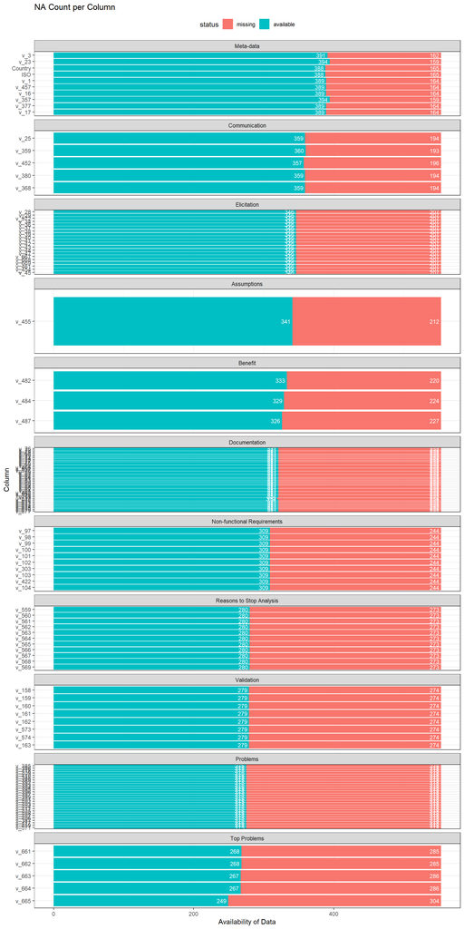

```r
d %>%
  summarise(across(everything(), ~ sum(is.na(.)))) %>%
  pivot_longer(cols = everything(),
                names_to = "column",
                values_to = "missing") %>%
  mutate(
    available = n - missing,
    group = factor(
      case_when(
        column %in% vars.meta ~ "Meta-data",
        column %in% vars.communication ~ "Communication",
        column %in% vars.elicitation ~ "Elicitation",
        column %in% vars.assumption ~ "Assumptions",
        column %in% vars.benefit ~ "Benefit",
        column %in% vars.documentation ~ "Documentation",
        column %in% vars.nfrs ~ "Non-functional Requirements",
        column %in% vars.reasons ~ "Reasons to Stop Analysis",
        column %in% vars.validation ~ "Validation",
        column %in% vars.problems ~ "Problems",
        column %in% vars.top ~ "Top Problems",
        .default = "Other"
      ), levels = c("Meta-data", "Communication", "Elicitation", "Assumptions",
                    "Benefit", "Documentation", "Non-functional Requirements",
                    "Reasons to Stop Analysis", "Validation", "Problems",
                    "Top Problems"),
      ordered = TRUE
    ),
    column = factor(column, levels = rev(vars), ordered = TRUE)
  ) %>%
  pivot_longer(cols = c("missing", "available"), names_to = "status", values_to = "count") %>%
  mutate(status = factor(status, levels = c("missing", "available"), ordered = FALSE)) %>%
  ggplot(aes(x = count, y = column, fill = status)) +
    geom_bar(stat = "identity", position = "stack") +
    geom_text(aes(label = count), position = "stack", stat = "identity",
              hjust = 1.2, colour = "white", size = 3) +
    labs(title = "NA Count per Column",
        x = "Availability of Data",
        y = "Column") +
    facet_wrap(~group, scales = "free_y", ncol = 1) +
    theme_bw() +
    theme(legend.position = "top")
```

The figure shows a gradual decline of data availability from around 389 responses to 268 responses. We generate the following, simplified figure to communicate the dropout pattern to readers.

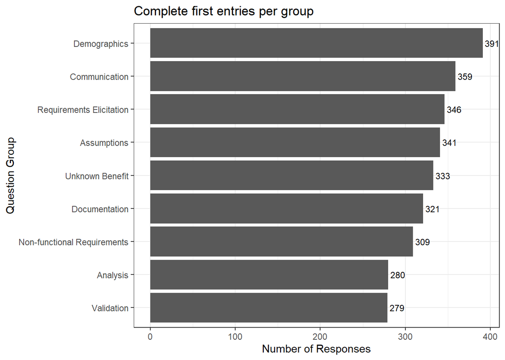

```r
d %>%
  select(v_3, v_25, v_28, v_455, v_482, v_76, v_97, v_559, v_158) %>%
  summarise(across(everything(), ~ sum(is.na(.)))) %>%
  pivot_longer(cols = everything(),
                names_to = "column",
                values_to = "missing") %>%
  mutate(available = n - missing) %>%
  mutate(
    column = factor(column, levels = rev(c("v_3", "v_25", "v_28", "v_455", "v_482",
                                       "v_76", "v_97", "v_559", "v_158")),
                    labels = rev(c("Demographics", "Communication", "Requirements Elicitation",
                               "Assumptions", "Unknown Benefit", "Documentation",
                               "Non-functional Requirements", "Analysis",
                               "Validation")), ordered = TRUE)
    ) %>%
   ggplot(aes(x = available, y = column)) +
    geom_bar(stat = "identity", position = "stack") +
    geom_text(aes(label = available), hjust = -0.15, size = 3.2) +
    labs(
      x = "Number of Responses",
      y = "Question Group",
      title = "Complete first entries per group") +
    theme_bw() +
    theme(legend.position = "right")
```

```r
ggsave("../../figures/dropout-page.pdf", device = "pdf",
       width = 16, height = 5, unit = "cm")
```

However, the survey tool recorded even incomplete pages. To accurately understand the dropout pattern, we first need to determine the number of complete responses per question group.

```r
completeness <- map_dfr(names(var_groups), function(g) {
  vars_g <- var_groups[[g]]
  d_sub <- d %>% select(any_of(vars_g))

  tibble(
    group      = g,
    n_min      = sum(complete.cases(d_sub)),                 # all vars in group non-NA
    n_max      = d_sub %>%
      summarise(across(everything(), ~ sum(!is.na(.)))) %>%
      as.numeric() %>%
      max()                                                   # best single variable
  )
})
```

The following figure contrasts these two values, showing the range between

- the minimum number of available data points per question group (i.e., the number of complete rows given the subset of questions), and
- the maximum number of available data points for one single question within that group.

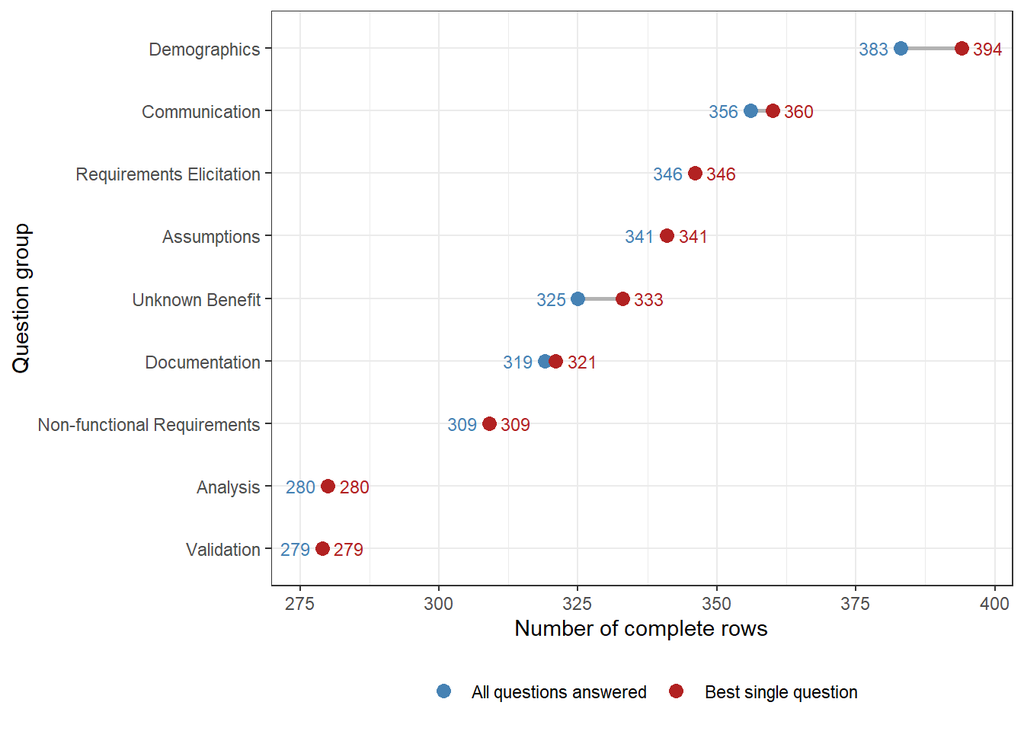

```r
ggplot(completeness, aes(y = fct_reorder(group, n_max))) +
  geom_segment(aes(x = n_min, xend = n_max, yend = group), color = "grey70", linewidth = 1) +
  geom_point(aes(x = n_min, color = "All questions answered"), size = 3) +
  geom_point(aes(x = n_max, color = "Best single question"), size = 3) +
  geom_text(aes(x = n_min, label = n_min), hjust = 1.4, size = 3.2, color = "steelblue") +
  geom_text(aes(x = n_max, label = n_max), hjust = -0.4, size = 3.2, color = "firebrick") +
  scale_color_manual(
    name = NULL,
    values = c(
      "All questions answered" = "steelblue",
      "Best single question"   = "firebrick"
    )
  ) +
  labs(x = "Number of complete rows", y = "Question group") +
  theme_bw() +
  theme(legend.position = "bottom") +
  scale_x_continuous(expand = expansion(mult = c(0.08, 0.08)))  # room for labels at both ends
```

```r
ggsave("../../figures/dropout-complete.pdf", device = "pdf",
       width = 12, height = 8, unit = "cm")
```